# Math 611 HW5

Jeff Gould

10/3/2020

### 1)

#### a) Write down an expression for $Q(\theta, \theta')$ using $r_{i1} = P(z_i=1 \ | \ \hat{X}_i, \theta)$, $r_{i2} = P(z_i = 2 \ | \ \hat{X}_i, \theta)$ and the pdfs of the normals. Then give a formula for $r_{i1}$ and $r_{i2}$ in terms of $\theta$ and the $\hat{X}_i$

$Q(\theta, \theta') = \sum_{i=1}^N E_\theta[\log P(\hat{X}_i, z_i \ | \ \theta')] =$

$P(X,z_i|\theta) = \prod_{i=1}^N p_1^{z_{i1}}\mathcal{N}(X_i|\mu_1, \sigma_1^2)^{z_{i1}} \cdot p_2^{z_{i2}}\mathcal{N}(X_i|\mu_2, \sigma_2^2)^{z_{i2}} \Rightarrow$

$\log P(X, z_i |\theta) = \sum_{i=1}^N z_{i1}[\log p_1 + \log \mathcal{N}(X_i|\mu_1,\sigma_1^2)] +z_{i2}[\log p_2 + \log \mathcal{N}(X_i|\mu_2,\sigma_2^2)]$

$\sum_{i=1}^N E_\theta[\log P(\hat{X}_i, z_i \ | \ \theta')] =\sum_{i=1}^N P(z_{i}=1)[\log p_1 + \log \mathcal{N}(X_i|\mu_1,\sigma_1^2)] +P(z_{i}=2)[\log p_2 + \log \mathcal{N}(X_i|\mu_2,\sigma_2^2)] =$

$\sum_{i=1}^N r_{i1}[\log p_1 + \log \mathcal{N}(X_i|\mu_1,\sigma_1^2)] +r_{i2}[\log p_2 + \log \mathcal{N}(X_i|\mu_2,\sigma_2^2)] =$

$\sum_{i=1}^N r_{i1}[\log p_1 + \log \frac{1}{\sqrt{2\pi\sigma_1^2}}e^{-(X_i-\mu_1)^2/(2\sigma_1^2)}] +r_{i2}[\log p_2 + \log \frac{1}{\sqrt{2\pi\sigma_1^2}}e^{-(X_i-\mu_1)^2/(2\sigma_1^2)}] =$

$\sum_{i=1}^N r_{i1}[\log p_1 + -(X_i-\mu_1)^2/(2\sigma_1^2) - \frac{1}{2}\log(2\pi\sigma_1^2)] +r_{i2}[\log p_2 + -(X_i-\mu_2)^2/(2\sigma_2^2) - \frac{1}{2}\log(2\pi\sigma_2^2)]$

$r_{i1} = \frac{p_1\mathcal{N}(X_i|\mu_1,\sigma_1^2)}{p_1\mathcal{N}(X_i|\mu_1,\sigma_1^2) +p_2\mathcal{N}(X_i|\mu_2,\sigma_2^2)}$

$r_{i2} = \frac{p_2\mathcal{N}(X_i|\mu_2,\sigma_2^2)}{p_1\mathcal{N}(X_i|\mu_1,\sigma_1^2) +p_2\mathcal{N}(X_i|\mu_2,\sigma_2^2)}$

#### b) Compute $\text{argmax}_{\theta'} Q(\theta, \theta')$

$\frac{\partial}{\partial p_1}\sum_{i=1}^N r_{i1}[\log p_1 + -(X_i-\mu_1)^2/(2\sigma_1^2) - \frac{1}{2}\log(2\pi\sigma_1^2)] +r_{i2}[\log p_2 + -(X_i-\mu_2)^2/(2\sigma_2^2) - \frac{1}{2}\log(2\pi\sigma_2^2)] =$

$\frac{\partial}{\partial p_1}\sum_{i=1}^N r_{i1}\log p_1+r_{i2}\log (1-p_1) = \frac{\sum r_{i1}}{p_1} + \frac{\sum r_{i2}}{1-p_1} = \frac{(1-p_1)\sum r_{i1}}{p_1(1-p_1)} + \frac{p_1 \sum r_{i2}}{p_1(1-p_1)} = 0 \rightarrow$

$(1-p_1)\sum r_{i1} + p_1 \sum r_{i2} = 0 \rightarrow p_1 = \frac{\sum r_{i1}}{\sum (r_{i1} + r_{i2})} = \frac{1}{N}\sum r_{i1}$, and by symmetry $p_2 = \frac{\sum r_{i2}}{\sum (r_{i1} + r_{i2})} = \frac{1}{N}\sum r_{i2}$

$\frac{\partial}{\partial \mu_1}\sum_{i=1}^N r_{i1}[\log p_1 + -(X_i-\mu_1)^2/(2\sigma_1^2) - \frac{1}{2}\log(2\pi\sigma_1^2)] +r_{i2}[\log p_2 + -(X_i-\mu_2)^2/(2\sigma_2^2) - \frac{1}{2}\log(2\pi\sigma_2^2)] =$

$\frac{\partial}{\partial \mu_1}\sum_{i=1}^N r_{i1}[ -(X_i-\mu_1)^2/(2\sigma_1^2)] = \sum_{i=1}^N r_{i1}(X_i-\mu_1)/\sigma_1^2 = 0 \rightarrow \sum_{i=1}^N r_{i1}(X_i-\mu_1) = 0$

$\sum_{i=1}^N r_{i1}(X_i-\mu_1) = \sum_{i=1}^N (r_{i1}X_i- r_{i1}\mu_1) = \sum_{i=1}^N r_{i1}X_i - \mu_1 \sum_{i=1}^N r_{i1} = 0 \rightarrow \sum_{i=1}^N r_{i1}X_i = \mu_1 \sum_{i=1}^N r_{i1} \rightarrow \mu_1 = \frac{\sum_{i=1}^N r_{i1}X_i}{\sum_{i=1}^N r_{i1}}$

By symmetry, solving $\frac{\partial}{\partial \mu_2}\sum_{i=1}^N r_{i1}[\log p_1 + -(X_i-\mu_1)^2/(2\sigma_1^2) - \frac{1}{2}\log(2\pi\sigma_1^2)] +r_{i2}[\log p_2 + -(X_i-\mu_2)^2/(2\sigma_2^2) - \frac{1}{2}\log(2\pi\sigma_2^2)]$for $\mu_2$, we get

$\mu_2 = \frac{\sum_{i=1}^N r_{i2}X_i}{\sum_{i=1}^N r_{i2}}$

$\frac{\partial}{\partial \sigma_1^2}\sum_{i=1}^N r_{i1}[\log p_1 + -(X_i-\mu_1)^2/(2\sigma_1^2) - \frac{1}{2}\log(2\pi\sigma_1^2)] +r_{i2}[\log p_2 + -(X_i-\mu_2)^2/(2\sigma_2^2) - \frac{1}{2}\log(2\pi\sigma_2^2)] =$

$\frac{\partial}{\partial \sigma_1^2}\sum_{i=1}^N r_{i1}[-(X_i-\mu_1)^2/(2\sigma_1^2) - \frac{1}{2}\log(\sigma_1^2)] = \sum_{i=1}^N r_{i1}\left(\frac{(X_i-\mu_1)^2}{2(\sigma_1^2)^2} -\frac{1}{2\sigma_1^2}\right)= \sum_{i=1}^N r_{i1}\left(\frac{(X_i-\mu_1)^2}{2(\sigma_1^2)^2} -\frac{\sigma_1^2}{2(\sigma_1^2)^2}\right) = 0 \rightarrow$

$\sum_{i=1}^N r_{i1}\left((X_i-\mu_1)^2 -\sigma_1^2\right) = 0 \rightarrow \sum_{i=1}^N r_{i1}(X_i-\mu_1)^2 = \sum_{i=1}^N r_{i1}\sigma_1^2 \Rightarrow$

$\sigma_1^2 = \frac{\sum_{i=1}^N r_{i1}(X_i-\mu_1)^2}{\sum_{i=1}^N r_{i1}}$

Again, by symmetry, $\sigma_2^2 = \frac{\sum_{i=1}^N r_{i2}(X_i-\mu_2)^2}{\sum_{i=1}^N r_{i2}}$

### 2)

#### a)

E-Step: Given $X$, $\theta = (\mu^{(1)}, \mu^{(2)}, p_1, p_2)$, and $p_1 +p_2 = 1$. If applying soft EM, calculate the probabily each $X_i$ is in the first or second distribution:

$z_{1i}' = p_1 P(X_i|\mu_1) =p_1 \prod_{d=1}^{10}\mu_{1d}^{X_{id}}(1-\mu_{1d})^{(1-X_{id})}$

$z_{2i}' = p_2 P(X_i|\mu_2) =p_2 \prod_{d=1}^{10}\mu_{2d}^{X_{id}}(1-\mu_{2d})^{(1-X_{id})}$

$z_{1i} = \frac{z_{1i}'}{z_{1i}' + z_{2i}'}$

$z_{2i} = \frac{z_{2i}'}{z_{1i}' + z_{2i}'}$

M-Step: Given $X$, $Z = (z_1 z_2)$, calculate $\theta = (\mu^{(1)}, \mu^{(2)}, p_1, p_2)$

$M1 = \sum z_1$, $M2 = \sum z_2$

$\mu_1 = \frac{1}{M1} \sum z_{i1}X_i$

$\mu_2 = \frac{1}{M2} \sum z_{i2}X_i$

$p_1 = \frac{M1}{M1 + M2}$

$p_2 = \frac{M2}{M1 + M2}$

log-likelihood:

$\log p(X|\theta) = \sum_{i=1}^N \log(p_1 P(X_i|\mu_1) +p_2 P(X_i|\mu_2))$

#### b)

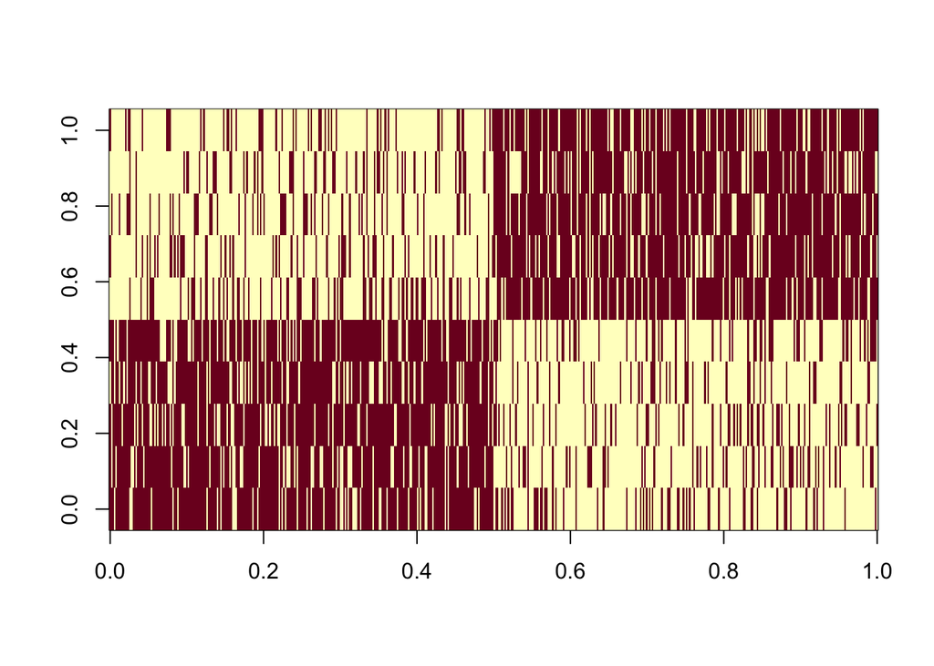

```r
noisy_bits <- read_csv("noisy_bits.csv")

noisy_bits %>% as.matrix() %>% image()
```

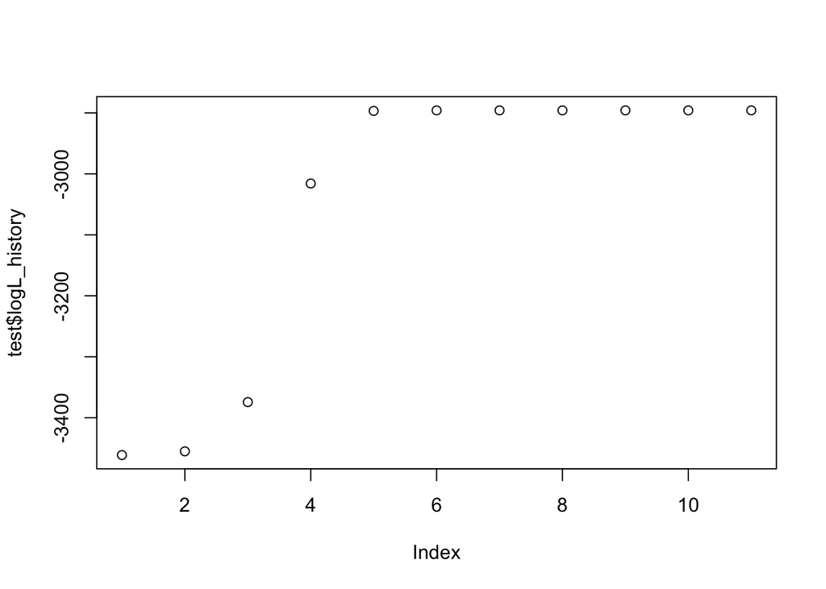

```r
e_step_soft <- function(x, theta){

  mu1 <- theta$Mu[1, ]
  mu2 <- theta$Mu[2, ]

  p1 <- theta$Pi[1]
  p2 <- theta$Pi[2]

  z1 <- p1 * (apply(X, 1, function(x)mapply(dbinom, x, mu1, size = 1) %>% prod()))

  z2 <- p2 * (apply(X, 1, function(x)mapply(dbinom, x, mu2, size = 1) %>% prod()))

  Z <- cbind(z1, z2) / rowSums(cbind(z1, z2))

  return(Z)

}



m_step_soft <- function(X, Z){

  M1 <- sum(Z[ ,1])
  M2 <- sum(Z[ ,2])

  mu1 <- 1/M1 * colSums(Z[,1] * X)
  mu2 <- 1/M2 * colSums(Z[,2] * X)

  obs <- nrow(X)

  Pi <- c(M1, M2) / sum(M1, M2)

  Mu <- rbind(mu1, mu2)

  theta <- list(Mu = Mu,  Pi = Pi)

  return(theta)

}

logLike <- function(X, theta){

  mu1 <- theta$Mu[1, ]
  mu2 <- theta$Mu[2, ]

  p1 <- theta$Pi[1]
  p2 <- theta$Pi[2]

  comp1 <- p1 * (apply(X, 1, function(x)mapply(dbinom, x, mu1, size = 1) %>% prod()))
  comp2 <- p2 * (apply(X, 1, function(x)mapply(dbinom, x, mu2, size = 1) %>% prod()))

  return(sum(log(comp1 + comp2)))

}

EM_soft <- function(X, init_Z, max_iter = 50, epsilon = 1e-3){

  for (i in 1:max_iter) {
    if (i == 1) {
      # Initialization
      m.step <- m_step_soft(X, init_Z)
      e.step <- e_step_soft(X, m.step)
      cur.loglik <- logLike(X, m.step)
      loglik.vector <- cur.loglik
    } else {
      # Repeat E and M steps till convergence
      m.step <- m_step_soft(X, e.step)
      e.step <- e_step_soft(X, m.step)

      cur.loglik <- logLike(X, m.step)
      loglik.vector <- c(loglik.vector, cur.loglik)

      loglik.diff <- abs(cur.loglik - loglik.vector[i-1])
      if(loglik.diff < epsilon & i > 10) {
        break
      }
    }
  }

  return(list(
    theta = m.step,
    logL_history = loglik.vector,
    probs = e.step
  ))
}

X <- noisy_bits %>% as.matrix()

init_Zs <-  matrix(runif(1000), ncol = 2)
init_Zs <- init_Zs / rowSums(init_Zs)
init_Z <- init_Zs

test <- EM_soft(X, init_Zs)
plot(test$logL_history)
```

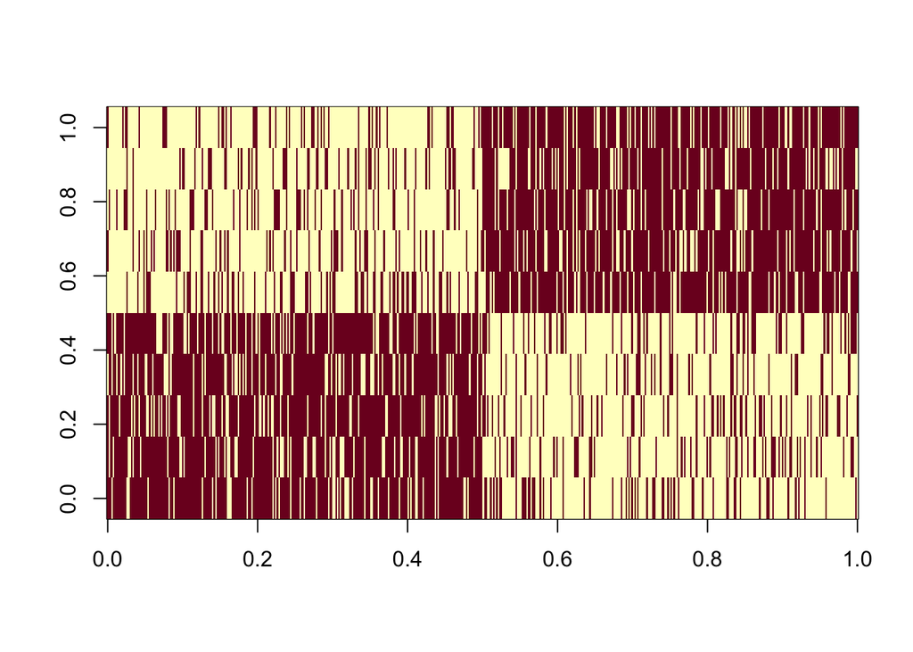

```r
image(X)
```

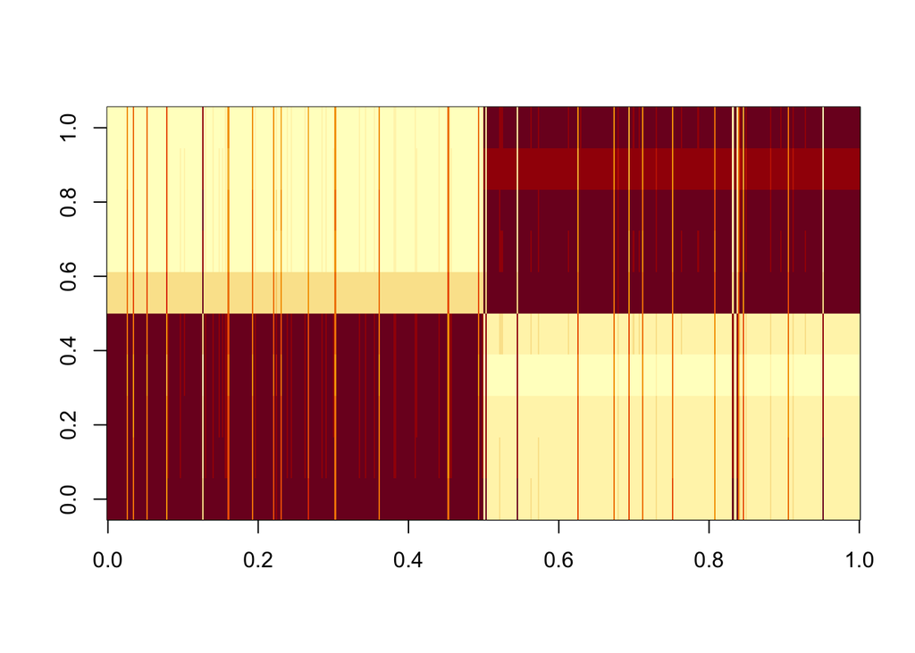

```r
X_result <- test[["probs"]][,1] * matrix(rep(test$theta$Mu[1,], 500), nrow = 500, byrow = T) + test[["probs"]][,2] * matrix(rep(test$theta$Mu[2,], 500), nrow = 500, byrow = T)
image(X_result)
```

```r
test$theta
```

```
## $Mu
##            V1        V2        V3        V4        V5        V6        V7
## mu1 0.2250306 0.2210770 0.2173989 0.1614023 0.2386598 0.8141468 0.7926998
## mu2 0.8090003 0.7851571 0.7808418 0.7683933 0.7758493 0.2793200 0.2053043
##            V8        V9       V10
## mu1 0.8121408 0.7537884 0.7926516
## mu2 0.2060544 0.2077925 0.1855540
##
## $Pi
## [1] 0.4948892 0.5051108
```

Correct classifications:

```r
mean(test[["probs"]][1:250,2] > 0.5)
```

```
## [1] 0.976
```

```r
mean(test[["probs"]][251:500,1] > 0.5)
```

```
## [1] 0.956
```

### 3

#### a) Let $a,b \in \mathbb{R}^n$ be column vectors. Show in any way you like - by proof, through example, by intuitive explanation - that $(a \cdot b)^2 = a^T M a$ where $M$ is an $n \times n$ matrix given by $M = bb^T$.

$(a \cdot b)^2 = (a \cdot b)(a \cdot b) = (a \cdot b)(b \cdot a) = (a \cdot b)(b^Ta) = a \cdot bb^Ta = a \cdot Ma = a^TMa$, where the last step follows because M is symmetric

#### b) Let $\hat{\Sigma}$ be the covariance matrix of the data. Then, by definition

$$\begin{equation}
\hat{\Sigma}_{jk} = \frac{1}{N} \sum_{i=1}^N (X^{(i)}_j - \mu_j)(X^{(i)}_k - \mu_k)
\end{equation}$$

Show that $\hat{\Sigma}$ can also be written in the following two forms

- Let $\tilde{X}$ be the $N \times n$ matrix with the $X^{(i)} - \mu$ as the rows

$$\begin{equation}
\hat{\Sigma} = \frac{1}{N} \tilde{X}^T \tilde{X}
\end{equation}$$

Let $C$ be the $n \times n$ matrix formed by $\tilde{X}^T\tilde{X}$. Then the $c_{jk}$ entry in $C$ is $\tilde{x}^T_{j1}\tilde{x}_{1k} + \tilde{x^T}_{j2}\tilde{x}_{2k} + \dots + \tilde{x}^T_{jN}\tilde{x}_{Nk} = \sum_{i=1}^N\tilde{X}_{ji}^T\tilde{X}_{ik} = \sum_{i=1}^N (X^{(i)}_j - \mu_j)(X^{(i)}_k - \mu_k)$

$\frac{1}{N} \tilde{X}^T \tilde{X} = \frac{1}{N}C$, so each entry in $\frac{1}{N} C = \frac{1}{N}\sum_{i=1}^N (X^{(i)}_j - \mu_j)(X^{(i)}_k - \mu_k)$ which is $\hat{\Sigma}$

- Thinking of the $X^{(i)}$ as column vectors,

$$\begin{equation}
\hat{\Sigma} = \frac{1}{N} \sum_{i=1}^N (X^{(i)} - \mu) (X^{(i)} - \mu)^T
\end{equation}$$

For each $(X^{(i)} - \mu) (X^{(i)} - \mu)^T$ we get an $n \times n$ matrix. The $jk^{th}$ entry in each matrix is $(X^{(i)}_{j}-\mu_j)(X^{(i)}_{k}-\mu_k)$

Then when we some up the matrices, the result is that each $jk^{th}$ entry in the resulting matrix is

$\sum_{i=1}^N (X^{(i)}_{j}-\mu_j)(X^{(i)}_{k}-\mu_k)$, and divide by $N$ to get $\hat{\Sigma}$.

#### c)

The 1-d PCA involves the parameters $\mu$, $w^{(1)}$ and $c_i \in \mathbb{R}$ for $i=1,2,\dots,N$ that are used to approximate $X^{(i)}$ according to

$$\begin{equation}
X^{(i)} \approx \mu + c_i w^{(1)}.
\end{equation}$$

Derive the values of $c_i$ and $w^{(1)}$ that optimize this approximation. (We did this in class.) Then, compute the mean and variance of the $c_i$

$l(w^{(1)}, c_1,\dots , c_N) = \sum_{i=1}^N ||\hat{X}^{(i)} - \mu - c_i w^{(1)}||^2 \rightarrow$

$\frac{\partial l}{\partial c_k} = \frac{\partial }{\partial c_k}||\hat{X}^{(k)} - \mu - c_k w^{(1)}||^2 = \frac{\partial }{\partial c_k} \left[ (\hat{X}^{(k)} - \mu - c_k w^{(1)}) \cdot (\hat{X}^{(k)} - \mu - c_k w^{(1)}) \right] = -2w^{(1)} \cdot (X^{(k)} - \mu - c_k w^{(1)}) = 0 \rightarrow$

$(X^{(k)} - \mu - c_k w^{(1)}) = 0 \rightarrow X^{(k)} = \mu + c_k w^{(1)}$

- compute the mean and variance of $C = (c_1, c_2, \dots c_N)$

$X^{(i)} = \mu + c_i w^{(1)} \rightarrow c_i = \frac{X^{(i)} - \mu}{w^{(1)}}$

$E[C] = E\left[\frac{X - \mu}{w^{(1)}} \right] = 0$

$Var(C) = Var\left[\frac{X - \mu}{w^{(1)}} \right] = \frac{1}{w^{(i)^2}}Var\left[X - \mu\right] = \frac{1}{w^{(i)^2}}Var(X)$